# Fitting the ST model for the LUR

Sheena Martenies

07/20/2020

# 1 Introduction

This version of the model builds on the analysis presented in `16b_LUR_BC_ST_NB`. There are some key changes to the model, described below.

Main take aways:

- It looks like these three models are performing comparably to the previous version that did not include PM2.5 in the trend data
- However, the 2-basis function model (Model B) still has some residual autocorrelation in at the central site
- This autocorrelation goes away when we use 3 trend functions, but then the predictions for the 2009-2019 period are different from what we expect

**Update 07/20/2020** After some prelimiary models, Josh offered some additional feedback:

- The model using three basis functions likely doesn’t have enough data to support it (which is good, because it wasn’t giving us believable results anyway)
- The trends in PM and NO2 might be influenced by some more extreme values, so I’m going to try log-transforming them first and then scaling the variables

# 2 Fit time trends

## 2.1 Denver data set

Here I’m reading in the filter data sets and getting them into the right shape for the `SpatioTemporal` package. Here the ST covariates cover the entire study period (2009 - 2019).

```r
data_name <- "Combined_Filter_Data_AEA.csv"
lur_data <- read_csv(here::here("Data", data_name)) %>%
  filter(!is.na(lon)) %>%
  filter(indoor == 0) %>%
  #' QA filters
  filter(bc_ug_m3_dem > 0) %>%
  filter(is.na(below_lod) | below_lod == 0) %>%
  filter(is.na(low_volume_flag) | low_volume_flag == 0) %>%
  filter(is.na(flow_rate_flag) | flow_rate_flag == 0) %>%
  filter(is.na(is_blank) | is_blank == 0) %>%
  filter(is.na(negative_pm_mass) | negative_pm_mass == 0) %>%
  filter(is.na(potential_contamination) | potential_contamination == 0) %>%
  #' Using Ben's LOD, but not imputing values
  filter(is.na(bc_mass_ug_corrected) | bc_mass_ug_corrected >= 1.41) %>%
  #' Just campaigns 1-3 and the monitoring site
  filter(campaign %in% paste0("Campaign", c(1, 2, 3, "X")))
lur_data <- lur_data %>%
  rename("bc_ug_m3_raw" = "bc_ug_m3") %>%
  rename("bc_ug_m3" = "bc_ug_m3_dem")

camp_data <- filter(lur_data, campaign %in% paste0("Campaign", c(1, 2, 3)))
nrow(camp_data)
```

```
## [1] 615
```

```r
summary(camp_data$bc_ug_m3)
```

```
##    Min. 1st Qu.  Median    Mean 3rd Qu.    Max.
##  0.7848  0.9567  1.0798  1.1544  1.3133  2.2748
```

```r
#' Format the date variable to be Year-WeekNo. (starts on Sunday)
#' Convert that back to the first day of the week
lur_data <- lur_data %>%
  mutate(sample_week_no = format(StartDateLocal, "%Y-%W")) %>%
  mutate(sample_week = as.Date(cut(as.Date(StartDateLocal), "week")))

#' Add a unique site ID
ids <- read_csv(here::here("Data", "ST_Model_Site_IDs.csv"))
lur_data <- mutate(lur_data, site_id_lonlat = paste(lon, lat, sep = "_"))
lur_data <- left_join(lur_data, ids, by = "site_id_lonlat")

lur_data$site_id <- ifelse(lur_data$filter_id == "080310027", "central", lur_data$site_id)

#' Create an ID object for the central site
cent_id <- filter(lur_data, filter_id == "080310027") %>%
  dplyr::select(site_id_lonlat) %>%
  distinct()

#' Drop old ST covariates
#' Keep linking variables (sample_week and site_id_lonlat)
lur_data <- dplyr::select(lur_data, -c(StartDateLocal:units_smoke))

#' Get the new ST covariates
st_covariates_file_name <- "ST_Covariates_Filters_09_19_AEA.csv"
st_covariates <- read_csv(here::here("Data", st_covariates_file_name)) %>%
  rename("sample_week" = "week") %>%
  filter(year(sample_week) < 2019) %>%
  left_join(ids, by = "site_id_lonlat") %>%
  filter(site_id_lonlat %in% lur_data$site_id_lonlat)
#' Duplicate st covariates for the central site monitor
cent_st_covariates <- filter(st_covariates, site_id_lonlat == cent_id$site_id_lonlat) %>%
  mutate(site_id = "central")

st_covariates <- bind_rows(st_covariates, cent_st_covariates)

st_cov_dates <- dplyr::select(st_covariates, site_id, sample_week) %>%
  distinct()

#' Log-transformed BC observations with NA values for the missing dates
bc_obs <- lur_data %>%
  dplyr::select(site_id, sample_week, bc_ug_m3) %>%
  mutate(log_bc = log(bc_ug_m3)) %>%
  dplyr::select(-bc_ug_m3)

#' Fill in the ST dates with NAs
bc_obs2 <- left_join(st_cov_dates, bc_obs, by = c("sample_week", "site_id"))

#' Pivot to a wide data frame
bc_obs2 <- bc_obs2 %>%
  pivot_wider(id_cols = sample_week,
              names_from = site_id, values_from = log_bc) %>%
              # names_from = site_id, values_from = bc_ug_m3) %>%
  as.data.frame() %>%
  arrange(sample_week)
rownames(bc_obs2) <- bc_obs2$sample_week
bc_obs2$sample_week <- NULL
bc_obs2 <- as.matrix(bc_obs2)

bc_weeks <- rownames(bc_obs2)

#' Spatial covariates (scaled)
load(here::here("Results", "BC_LASSO_Model_3C.Rdata"))

lasso_coef_df <- data.frame(name = log_bc_lasso_coef3@Dimnames[[1]][log_bc_lasso_coef3@i + 1],
                            coefficient = log_bc_lasso_coef3@x)
covars <- as.character(lasso_coef_df$name[-c(1:2)])
covars
```

```
##  [1] "impervious_2500"     "open_2500"           "low_int_100"
##  [4] "med_int_50"          "high_int_50"         "high_int_100"
##  [7] "ag_250"              "pop_den_50"          "dist_m_compost"
## [10] "dist_m_military"     "len_m_highways_2500" "aadt_100"
## [13] "aadt_2500"
```

```r
covar_fun <- paste("~", paste(covars, collapse = " + "))
covar_fun
```

```
## [1] "~ impervious_2500 + open_2500 + low_int_100 + med_int_50 + high_int_50 + high_int_100 + ag_250 + pop_den_50 + dist_m_compost + dist_m_military + len_m_highways_2500 + aadt_100 + aadt_2500"
```

```r
bc_sp_cov <- dplyr::select(lur_data, site_id, lon, lat, all_of(covars)) %>%
  distinct() %>%
  mutate_at(.vars = vars(covars),
            scale)
```

```
## Note: Using an external vector in selections is ambiguous.
## i Use `all_of(covars)` instead of `covars` to silence this message.
## i See <https://tidyselect.r-lib.org/reference/faq-external-vector.html>.
```

```r
bc_sp_cov <- bc_sp_cov %>%
  rename(ID = site_id) %>%
  mutate(lon2 = lon, lat2 = lat) %>%
  st_as_sf(coords = c("lon2", "lat2"), crs = ll_wgs84) %>%
  st_transform(crs = albers)
sp_coords <- do.call(rbind, st_geometry(bc_sp_cov)) %>% as_tibble()
names(sp_coords) <- c("x", "y")

bc_sp_cov <- bind_cols(bc_sp_cov, sp_coords) %>%
  st_set_geometry(NULL) %>%
  as.data.frame()

bc_sp_cov$type <- ifelse(bc_sp_cov$ID == "central", "central", "dist")
bc_sp_cov$type <- as.factor(bc_sp_cov$type)

cor(bc_sp_cov[,covars])
```

```
##                     impervious_2500   open_2500 low_int_100  med_int_50
## impervious_2500          1.00000000 -0.83510376  0.04147581 -0.16679293
## open_2500               -0.83510376  1.00000000 -0.12603064 -0.05636061
## low_int_100              0.04147581 -0.12603064  1.00000000 -0.12631919
## med_int_50              -0.16679293 -0.05636061 -0.12631919  1.00000000
## high_int_50              0.47483018 -0.41635316 -0.40185252  0.11602031
## high_int_100             0.52311084 -0.42248110 -0.42323883  0.11793239
## ag_250                  -0.27936743  0.21175032 -0.08010687 -0.01607492
## pop_den_50               0.38882480 -0.43039859  0.47294767  0.03873098
## dist_m_compost          -0.23740048  0.36015952 -0.11994547  0.24386038
## dist_m_military         -0.03254975  0.04081092  0.04177673 -0.27904653
## len_m_highways_2500      0.64494301 -0.49689181 -0.03038655 -0.07783019
## aadt_100                 0.42486549 -0.34876292 -0.28464438  0.03359576
## aadt_2500                0.46380170 -0.30096796 -0.07081120 -0.13990581
##                     high_int_50 high_int_100      ag_250  pop_den_50
## impervious_2500      0.47483018  0.523110836 -0.27936743  0.38882480
## open_2500           -0.41635316 -0.422481096  0.21175032 -0.43039859
## low_int_100         -0.40185252 -0.423238827 -0.08010687  0.47294767
## med_int_50           0.11602031  0.117932388 -0.01607492  0.03873098
## high_int_50          1.00000000  0.897420410 -0.06773259 -0.03835657
## high_int_100         0.89742041  1.000000000 -0.11729969 -0.05518337
## ag_250              -0.06773259 -0.117299694  1.00000000 -0.25195719
## pop_den_50          -0.03835657 -0.055183373 -0.25195719  1.00000000
## dist_m_compost      -0.10560558 -0.103918047  0.17279043 -0.12463877
## dist_m_military      0.02312569  0.005546725 -0.07173031 -0.06287839
## len_m_highways_2500  0.27706123  0.341931815 -0.24170133  0.03982997
## aadt_100             0.62883088  0.784232910 -0.10573403 -0.09971011
## aadt_2500            0.18533105  0.271784649 -0.11425336 -0.06750291
##                     dist_m_compost dist_m_military len_m_highways_2500
## impervious_2500        -0.23740048    -0.032549751         0.644943011
## open_2500               0.36015952     0.040810919        -0.496891814
## low_int_100            -0.11994547     0.041776735        -0.030386550
## med_int_50              0.24386038    -0.279046527        -0.077830187
## high_int_50            -0.10560558     0.023125694         0.277061226
## high_int_100           -0.10391805     0.005546725         0.341931815
## ag_250                  0.17279043    -0.071730306        -0.241701329
## pop_den_50             -0.12463877    -0.062878388         0.039829971
## dist_m_compost          1.00000000    -0.738189101        -0.086198948
## dist_m_military        -0.73818910     1.000000000        -0.008127746
## len_m_highways_2500    -0.08619895    -0.008127746         1.000000000
## aadt_100               -0.13357005     0.131174981         0.433081107
## aadt_2500               0.03881186    -0.225380937         0.475034135
##                        aadt_100   aadt_2500
## impervious_2500      0.42486549  0.46380170
## open_2500           -0.34876292 -0.30096796
## low_int_100         -0.28464438 -0.07081120
## med_int_50           0.03359576 -0.13990581
## high_int_50          0.62883088  0.18533105
## high_int_100         0.78423291  0.27178465
## ag_250              -0.10573403 -0.11425336
## pop_den_50          -0.09971011 -0.06750291
## dist_m_compost      -0.13357005  0.03881186
## dist_m_military      0.13117498 -0.22538094
## len_m_highways_2500  0.43308111  0.47503413
## aadt_100             1.00000000  0.21952160
## aadt_2500            0.21952160  1.00000000
```

```r
#' NO2 and smoke spatiotemporal predictors
#' NO2 at each site estimated using IDW
bc_st_no2 <- dplyr::select(st_covariates, site_id, sample_week, idw_no2) %>%
  pivot_wider(id_cols = sample_week,
              names_from = site_id, values_from = idw_no2) %>%
  as.data.frame()
rownames(bc_st_no2) <- bc_st_no2$sample_week
bc_st_no2$sample_week <- NULL
bc_st_no2 <- as.matrix(bc_st_no2)

no2_weeks <- rownames(bc_st_no2)
setdiff(bc_weeks, no2_weeks)
```

```
## character(0)
```

```r
#' Smoke day indicator variable based on WFS paper method (see Brey and Fischer, 2016)
bc_st_smk <- dplyr::select(st_covariates, site_id, sample_week, area_smoke_2sd) %>%
  pivot_wider(id_cols = sample_week,
              names_from = site_id, values_from = area_smoke_2sd) %>%
  as.data.frame()
rownames(bc_st_smk) <- bc_st_smk$sample_week
bc_st_smk$sample_week <- NULL
bc_st_smk <- as.matrix(bc_st_smk)

smk_weeks <- rownames(bc_st_smk)

setdiff(bc_weeks, smk_weeks)
```

```
## character(0)
```

Create a new `denver.data` object.

```r
denver.data <- createSTdata(obs = bc_obs2,
                            covars = bc_sp_cov,
                            SpatioTemporal = list(bc_st_no2 = bc_st_no2,
                                                  bc_st_smk = bc_st_smk))
D <- createDataMatrix(denver.data)
denver.data
```

```
## STdata-object with:
##  No. locations: 61 (observed: 61)
##  No. time points: 148 (observed: 148)
##  No. obs: 763
##
## Only constant temporal trend,with dates:
##  2016-02-08 to 2018-12-31
##
## 19 covariate(s):
##  [1] "ID"                  "lon"                 "lat"
##  [4] "impervious_2500"     "open_2500"           "low_int_100"
##  [7] "med_int_50"          "high_int_50"         "high_int_100"
## [10] "ag_250"              "pop_den_50"          "dist_m_compost"
## [13] "dist_m_military"     "len_m_highways_2500" "aadt_100"
## [16] "aadt_2500"           "x"                   "y"
## [19] "type"
##
## 2 spatio-temporal covariate(s):
## [1] "bc_st_no2" "bc_st_smk"
##
## All sites:
## central    dist
##       1      60
## Observed:
## central    dist
##       1      60
##
## For central:
##   Number of obs: 148
##   Dates: 2016-02-08 to 2018-12-31
## For dist:
##   Number of obs: 615
##   Dates: 2018-05-07 to 2018-11-12
```

## 2.2 Creating the NO2, BC, and PM data objects

Next we need to combine monitoring data for NO2, BC, and PM2.5 in order to calculate the time trends.

First up: NO2

Plot the time trends for NO2 at the monitors

**Original units (ppb)**

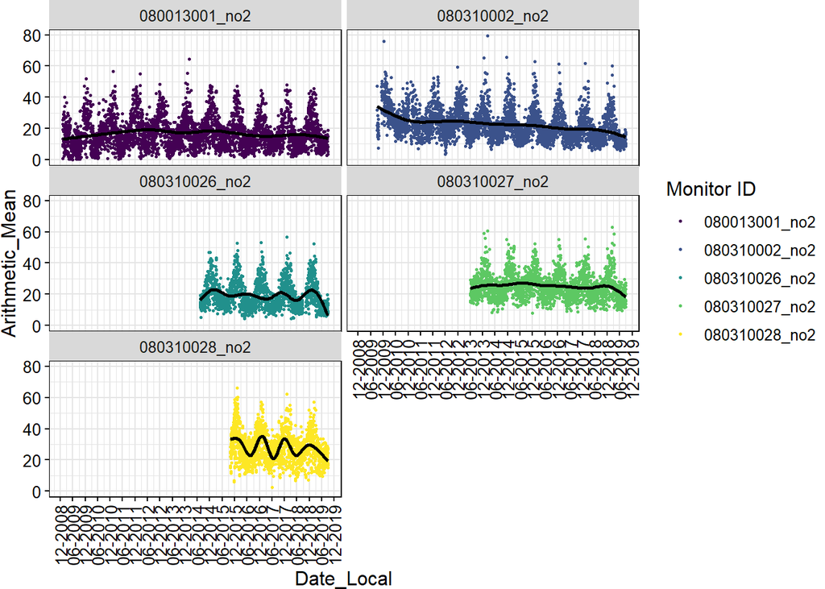

```r
no2_ts <- ggplot(data = no2_data, aes(x = Date_Local, y = Arithmetic_Mean)) +
  geom_point(aes(color = as.factor(monitor_id)), shape = 20, size = 1) +
  geom_smooth(se = F, color = "black", method = "gam") +
  scale_color_viridis(name = "Monitor ID", discrete = T) +
  scale_x_date(date_breaks = "6 months", date_labels = "%m-%Y") +
  facet_wrap(. ~ monitor_id, scales = "fixed", ncol = 2) +
  theme(axis.text.x = element_text(angle = 90, vjust = 0.5, hjust=1)) +
  simple_theme
no2_ts
```

**Log-transformed NO2**

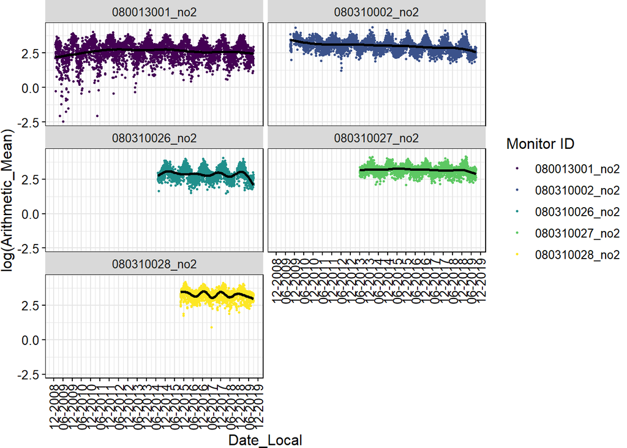

```r
no2_ts2 <- ggplot(data = no2_data, aes(x = Date_Local, y = log(Arithmetic_Mean))) +
  geom_point(aes(color = as.factor(monitor_id)), shape = 20, size = 1) +
  geom_smooth(se = F, color = "black", method = "gam") +
  scale_color_viridis(name = "Monitor ID", discrete = T) +
  scale_x_date(date_breaks = "6 months", date_labels = "%m-%Y") +
  facet_wrap(. ~ monitor_id, scales = "fixed", ncol = 2) +
  theme(axis.text.x = element_text(angle = 90, vjust = 0.5, hjust=1)) +
  simple_theme
no2_ts2
```

**Log-transformed NO2** with a higher value for k in the smoothed term

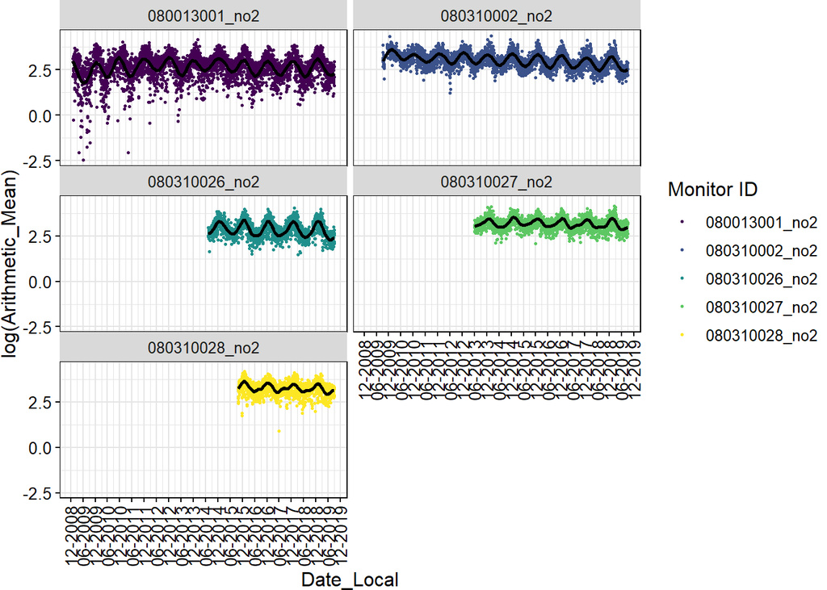

```r
no2_ts3 <- ggplot(data = no2_data, aes(x = Date_Local, y = log(Arithmetic_Mean))) +
  geom_point(aes(color = as.factor(monitor_id)), shape = 20, size = 1) +
  geom_smooth(se = F, color = "black", method = "gam", formula = y ~ s(x, k = 30)) +
  scale_color_viridis(name = "Monitor ID", discrete = T) +
  scale_x_date(date_breaks = "6 months", date_labels = "%m-%Y") +
  facet_wrap(. ~ monitor_id, scales = "fixed", ncol = 2) +
  theme(axis.text.x = element_text(angle = 90, vjust = 0.5, hjust=1)) +
  simple_theme
no2_ts3
```

Organize the observations and spatial data. **Use the log-transformed NO2 here**

```r
#' NO2 observations
no2_obs <- no2_data %>%
  dplyr::select(monitor_id, Date_Local, Arithmetic_Mean) %>%
  mutate(sample_week = as.character(as.Date(cut(as.Date(Date_Local), "week")))) %>%
  filter(sample_week %in% bc_weeks) %>%
  group_by(monitor_id, sample_week) %>%
  mutate(log_mean = log(Arithmetic_Mean)) %>%
  summarize(no2 = mean(log_mean, na.rm=T)) %>%
  pivot_wider(id_cols = sample_week,
              names_from = monitor_id, values_from = no2) %>%
  as.data.frame() %>%
  arrange(sample_week)
head(no2_obs)
```

|  | sample_week | 080013001_no2 | 080310002_no2 | 080310026_no2 | 080310027_no2 | 080310028_no2 |
| --- | --- | --- | --- | --- | --- | --- |
| 1 | 2008-12-29 | 2.431342 | NA | NA | NA | NA |
| 2 | 2009-01-05 | 2.333715 | NA | NA | NA | NA |
| 3 | 2009-01-12 | 3.095382 | NA | NA | NA | NA |
| 4 | 2009-01-19 | 2.496067 | NA | NA | NA | NA |
| 5 | 2009-01-26 | 2.644585 | NA | NA | NA | NA |
| 6 | 2009-02-02 | 2.983525 | NA | NA | NA | NA |

```r
# NO2 SP object
no2_data2 <- read_csv(here::here("Data", "Monitor_NO2_Data_AEA.csv")) %>%
  mutate(year = year(Date_Local)) %>%
  filter(year %in% c(2009:2019)) %>%
  dplyr::select(-year) %>%
  st_as_sf(wkt = "WKT", crs = albers) %>%
  mutate(monitor_id = paste0(monitor_id, "_no2")) %>%
  filter(monitor_id %in% colnames(no2_obs))
no2_coords <- do.call(rbind, st_geometry(no2_data2)) %>% as_tibble()
names(no2_coords) <- c("x", "y")
no2_sp_lonlat <- no2_data2 %>%
  st_transform(crs = ll_wgs84)
no2_coords2 <- do.call(rbind, st_geometry(no2_sp_lonlat)) %>%
  as_tibble() %>% setNames(c("lon","lat"))

no2_sp_cov <- st_set_geometry(no2_data2, NULL) %>%
  dplyr::select(monitor_id) %>%
  rename(ID = monitor_id)
no2_sp_cov <- bind_cols(no2_sp_cov, no2_coords, no2_coords2) %>%
  as.data.frame() %>%
  distinct()
```

Next, BC at the central site monitor

```r
#' BC central site concentrations
bc_cent_data <- read_csv(here::here("Data", "Monitor_BC_Data_AEA.csv")) %>%
  mutate(year = year(Date_Local)) %>%
  filter(year %in% c(2009:2019)) %>%
  dplyr::select(-year) %>%
  filter(County_Code %in% counties) %>%
  arrange(Date_Local, monitor_id) %>%
  mutate(Arithmetic_Mean = ifelse(Arithmetic_Mean <= 0.005, NA, Arithmetic_Mean))
#' Add an identifier to differentiate these measurements from collocated pollutants at the same site
bc_cent_data$monitor_id <- paste0(bc_cent_data$monitor_id, "_bc")
unique(bc_cent_data$monitor_id)
```

```
## [1] "080310027_bc"
```

Plot the time trends for BC at the central site monitor

**Original units (ug/m3)**

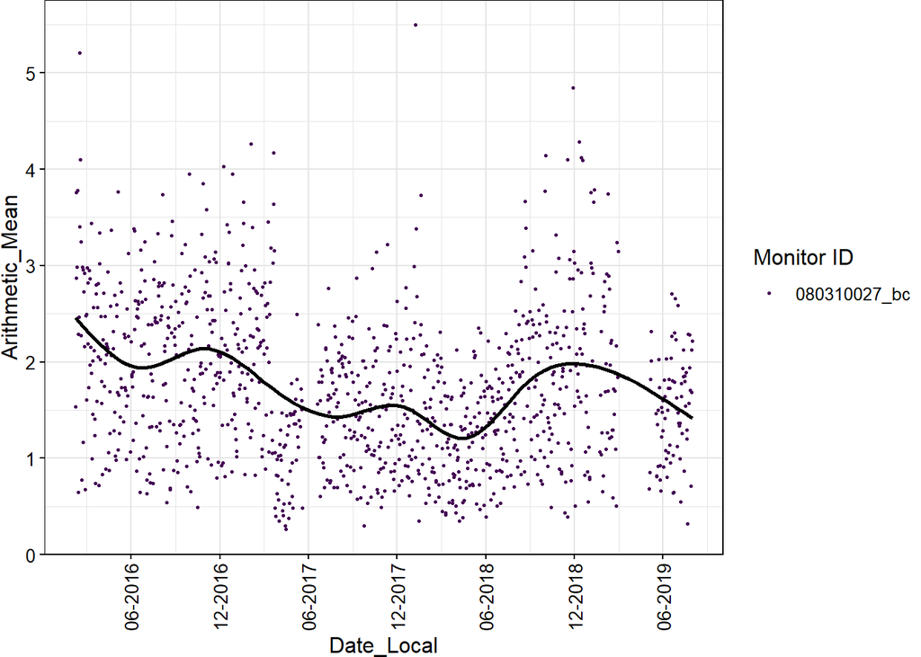

```r
bc_ts <- ggplot(data = bc_cent_data, aes(x = Date_Local, y = Arithmetic_Mean)) +
  geom_point(aes(color = as.factor(monitor_id)), shape = 20, size = 1) +
  geom_smooth(se = F, color = "black", method = "gam") +
  scale_color_viridis(name = "Monitor ID", discrete = T) +
  scale_x_date(date_breaks = "6 months", date_labels = "%m-%Y") +
  #facet_wrap(. ~ monitor_id, scales = "fixed", ncol = 2) +
  theme(axis.text.x = element_text(angle = 90, vjust = 0.5, hjust=1)) +
  simple_theme
bc_ts
```

**Log-transformed BC**

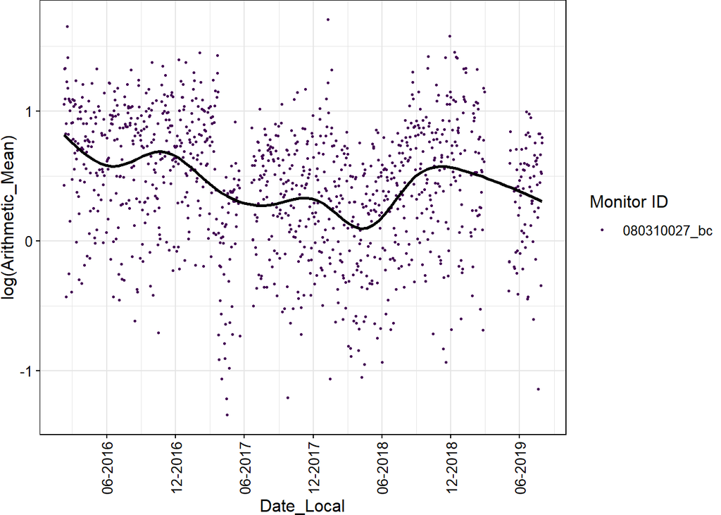

```r
bc_ts2 <- ggplot(data = bc_cent_data, aes(x = Date_Local, y = log(Arithmetic_Mean))) +
  geom_point(aes(color = as.factor(monitor_id)), shape = 20, size = 1) +
  geom_smooth(se = F, color = "black") +
  scale_color_viridis(name = "Monitor ID", discrete = T) +
  scale_x_date(date_breaks = "6 months", date_labels = "%m-%Y") +
  #facet_wrap(. ~ monitor_id, scales = "fixed", ncol = 2) +
  theme(axis.text.x = element_text(angle = 90, vjust = 0.5, hjust=1)) +
  simple_theme
bc_ts2
```

Organize the observations and spatial data

**Use log-transformed data here**

```r
#' BC observations
bc_cent_obs <- bc_cent_data %>%
  dplyr::select(monitor_id, Date_Local, Arithmetic_Mean) %>%
  mutate(sample_week = as.character(as.Date(cut(as.Date(Date_Local), "week")))) %>%
  filter(sample_week %in% bc_weeks) %>%
  group_by(monitor_id, sample_week) %>%
  mutate(log_mean = log(Arithmetic_Mean)) %>%
  summarize(bc = mean(log_mean, na.rm=T)) %>%
  pivot_wider(id_cols = sample_week,
              names_from = monitor_id, values_from = bc) %>%
  as.data.frame() %>%
  arrange(sample_week)
head(bc_cent_obs)
```

|  | sample_week | 080310027_bc |
| --- | --- | --- |
| 1 | 2016-02-08 | 0.8033350 |
| 2 | 2016-02-15 | 0.9907412 |
| 3 | 2016-02-22 | 0.6828013 |
| 4 | 2016-02-29 | 0.8227103 |
| 5 | 2016-03-07 | 0.7769437 |
| 6 | 2016-03-14 | 0.4305464 |

```r
# BC Central Site SP object
bc_cent_data2 <- read_csv(here::here("Data", "Monitor_BC_Data_AEA.csv")) %>%
  mutate(year = year(Date_Local)) %>%
  filter(year %in% c(2009:2019)) %>%
  dplyr::select(-year) %>%
  st_as_sf(wkt = "WKT", crs = albers) %>%
  mutate(monitor_id = paste0(monitor_id, "_bc")) %>%
  filter(monitor_id %in% colnames(bc_cent_obs))
bc_cent_coords <- do.call(rbind, st_geometry(bc_cent_data2)) %>% as_tibble()
names(bc_cent_coords) <- c("x", "y")
bc_cent_sp_lonlat <- bc_cent_data2 %>%
  st_transform(crs = ll_wgs84)
bc_cent_coords2 <- do.call(rbind, st_geometry(bc_cent_sp_lonlat)) %>%
  as_tibble() %>% setNames(c("lon","lat"))

bc_cent_sp_cov <- st_set_geometry(bc_cent_data2, NULL) %>%
  dplyr::select(monitor_id) %>%
  rename(ID = monitor_id)
bc_cent_sp_cov <- bind_cols(bc_cent_sp_cov, bc_cent_coords, bc_cent_coords2) %>%
  as.data.frame() %>%
  distinct()
```

Plot the time trends for PM2.5 at the monitors

**Original units (ug/m3)**

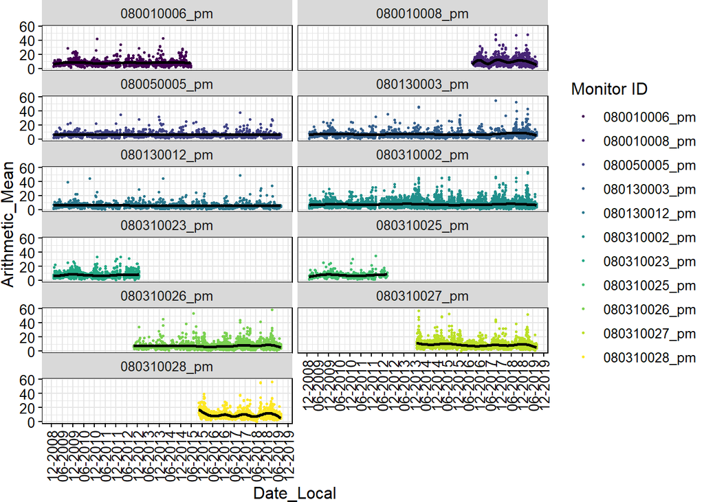

```r
pm_ts <- ggplot(data = pm_data, aes(x = Date_Local, y = Arithmetic_Mean)) +
  geom_point(aes(color = as.factor(monitor_id)), shape = 20, size = 1) +
  geom_smooth(se = F, color = "black") +
  scale_color_viridis(name = "Monitor ID", discrete = T) +
  scale_x_date(date_breaks = "6 months", date_labels = "%m-%Y") +
  facet_wrap(. ~ monitor_id, scales = "fixed", ncol = 2) +
  theme(axis.text.x = element_text(angle = 90, vjust = 0.5, hjust=1)) +
  simple_theme
pm_ts
```

**Log-transformed PM2.5**

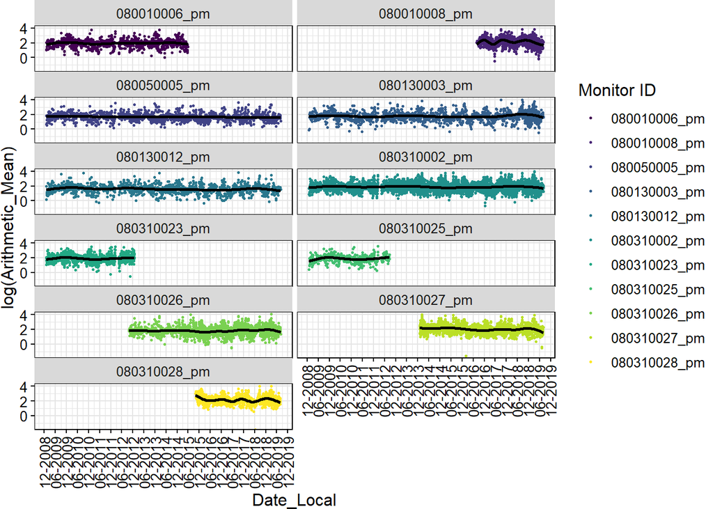

```r
pm_ts2 <- ggplot(data = pm_data, aes(x = Date_Local, y = log(Arithmetic_Mean))) +
  geom_point(aes(color = as.factor(monitor_id)), shape = 20, size = 1) +
  geom_smooth(se = F, color = "black", method = "gam") +
  scale_color_viridis(name = "Monitor ID", discrete = T) +
  scale_x_date(date_breaks = "6 months", date_labels = "%m-%Y") +
  facet_wrap(. ~ monitor_id, scales = "fixed", ncol = 2) +
  theme(axis.text.x = element_text(angle = 90, vjust = 0.5, hjust=1)) +
  simple_theme
pm_ts2
```

**Log-transformed PM2.5** with a higher value for k in the smoothed term

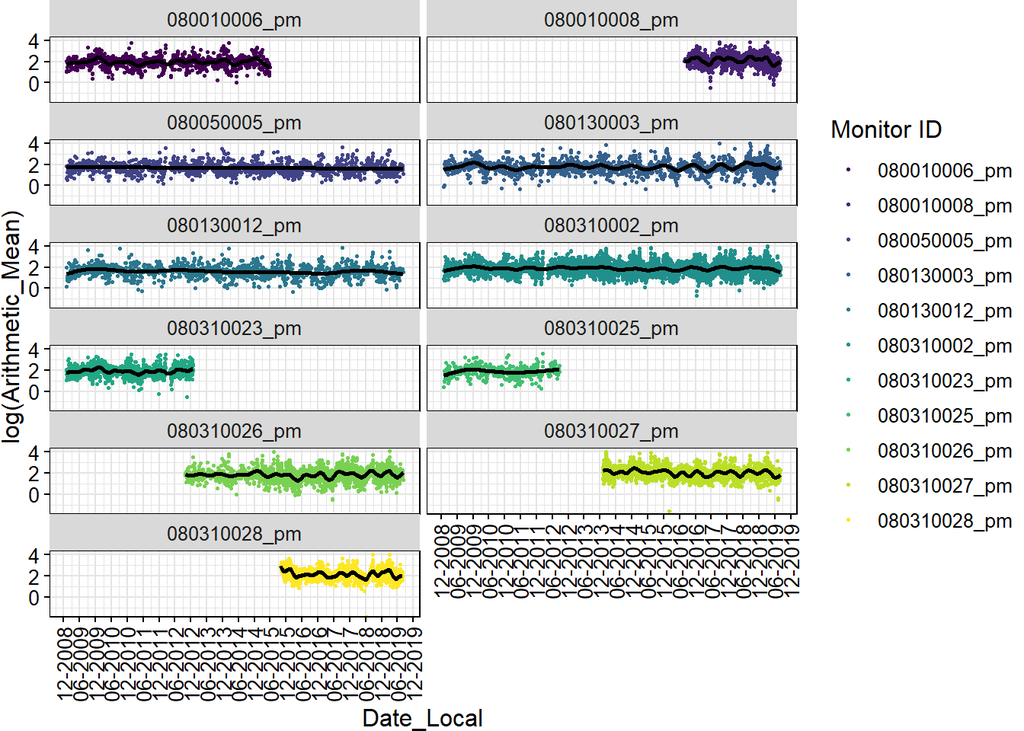

```r
pm_ts3 <- ggplot(data = pm_data, aes(x = Date_Local, y = log(Arithmetic_Mean))) +
  geom_point(aes(color = as.factor(monitor_id)), shape = 20, size = 1) +
  geom_smooth(se = F, color = "black", method = "gam", formula = y ~ s(x, k = 30)) +
  scale_color_viridis(name = "Monitor ID", discrete = T) +
  scale_x_date(date_breaks = "6 months", date_labels = "%m-%Y") +
  facet_wrap(. ~ monitor_id, scales = "fixed", ncol = 2) +
  theme(axis.text.x = element_text(angle = 90, vjust = 0.5, hjust=1)) +
  simple_theme
pm_ts3
```

Organize the observations and spatial data

**Use the log-transformed data here**

```r
#' PM2.5 observations
pm_obs <- pm_data %>%
  dplyr::select(monitor_id, Date_Local, Arithmetic_Mean) %>%
  mutate(sample_week = as.character(as.Date(cut(as.Date(Date_Local), "week")))) %>%
  filter(sample_week %in% bc_weeks) %>%
  group_by(monitor_id, sample_week) %>%
  mutate(log_mean = log(Arithmetic_Mean)) %>%
  summarize(pm = mean(log_mean, na.rm=T)) %>%
  pivot_wider(id_cols = sample_week,
              names_from = monitor_id, values_from = pm) %>%
  as.data.frame() %>%
  arrange(sample_week)
head(pm_obs)
```

|  | sample_week | 080010006_pm | 080010008_pm | 080050005_pm | 080130003_pm | 080130012_pm | 080310002_pm | 080310023_pm | 080310025_pm | 080310026_pm | 080310027_pm | 080310028_pm |
| --- | --- | --- | --- | --- | --- | --- | --- | --- | --- | --- | --- | --- |
| 1 | 2008-12-29 | 1.394118 | NA | 1.2490759 | 0.9679299 | 1.0919008 | 1.335209 | 1.661197 | 1.1537863 | NA | NA | NA |
| 2 | 2009-01-05 | 1.247789 | NA | 0.6817687 | 0.8243293 | 0.8908546 | 1.188381 | 1.513911 | 0.9359011 | NA | NA | NA |
| 3 | 2009-01-12 | 1.934844 | NA | 1.3697744 | 2.1047287 | 1.2511276 | 1.767997 | 1.919262 | 1.3262687 | NA | NA | NA |
| 4 | 2009-01-19 | 2.298456 | NA | 1.7730816 | 1.7212142 | 1.2703657 | 2.027844 | 1.996528 | 1.9969858 | NA | NA | NA |
| 5 | 2009-01-26 | 1.598321 | NA | 1.1939225 | 1.9059908 | 0.8047190 | 1.486213 | 1.909773 | 1.6521301 | NA | NA | NA |
| 6 | 2009-02-02 | 1.757461 | NA | 1.1728223 | 1.6964146 | 1.1689761 | 1.779227 | 1.729337 | 1.2870689 | NA | NA | NA |

```r
# PM SP object
pm_data2 <- read_csv(here::here("Data", "Monitor_PM_Data_AEA.csv")) %>%
  mutate(year = year(Date_Local)) %>%
  filter(year %in% c(2009:2019)) %>%
  dplyr::select(-year) %>%
  st_as_sf(wkt = "WKT", crs = albers) %>%
  mutate(monitor_id = paste0(monitor_id, "_pm")) %>%
  filter(monitor_id %in% colnames(pm_obs))
pm_coords <- do.call(rbind, st_geometry(pm_data2)) %>% as_tibble()
names(pm_coords) <- c("x", "y")
pm_sp_lonlat <- pm_data2 %>%
  st_transform(crs = ll_wgs84)
pm_coords2 <- do.call(rbind, st_geometry(pm_sp_lonlat)) %>%
  as_tibble() %>% setNames(c("lon","lat"))

pm_sp_cov <- st_set_geometry(pm_data2, NULL) %>%
  dplyr::select(monitor_id) %>%
  rename(ID = monitor_id)
pm_sp_cov <- bind_cols(pm_sp_cov, pm_coords, pm_coords2) %>%
  as.data.frame() %>%
  distinct()
```

Combine the observations and the spatial covariates Scale the pollutant measurements

```r
#' Join log-transformed observations
pol_obs <- left_join(no2_obs, bc_cent_obs, by = "sample_week") %>%
  left_join(pm_obs, by = "sample_week")
glimpse(pol_obs)
```

```
## Rows: 521
## Columns: 18
## $ sample_week     <chr> "2008-12-29", "2009-01-05", "2009-01-12", "2009-01-...
## $ `080013001_no2` <dbl> 2.4313422, 2.3337153, 3.0953820, 2.4960668, 2.64458...
## $ `080310002_no2` <dbl> NA, NA, NA, NA, NA, NA, NA, NA, NA, NA, NA, NA, NA,...
## $ `080310026_no2` <dbl> NA, NA, NA, NA, NA, NA, NA, NA, NA, NA, NA, NA, NA,...
## $ `080310027_no2` <dbl> NA, NA, NA, NA, NA, NA, NA, NA, NA, NA, NA, NA, NA,...
## $ `080310028_no2` <dbl> NA, NA, NA, NA, NA, NA, NA, NA, NA, NA, NA, NA, NA,...
## $ `080310027_bc`  <dbl> NA, NA, NA, NA, NA, NA, NA, NA, NA, NA, NA, NA, NA,...
## $ `080010006_pm`  <dbl> 1.394118, 1.247789, 1.934844, 2.298456, 1.598321, 1...
## $ `080010008_pm`  <dbl> NA, NA, NA, NA, NA, NA, NA, NA, NA, NA, NA, NA, NA,...
## $ `080050005_pm`  <dbl> 1.2490759, 0.6817687, 1.3697744, 1.7730816, 1.19392...
## $ `080130003_pm`  <dbl> 0.9679299, 0.8243293, 2.1047287, 1.7212142, 1.90599...
## $ `080130012_pm`  <dbl> 1.0919008, 0.8908546, 1.2511276, 1.2703657, 0.80471...
## $ `080310002_pm`  <dbl> 1.335209, 1.188381, 1.767997, 2.027844, 1.486213, 1...
## $ `080310023_pm`  <dbl> 1.661197, 1.513911, 1.919262, 1.996528, 1.909773, 1...
## $ `080310025_pm`  <dbl> 1.1537863, 0.9359011, 1.3262687, 1.9969858, 1.65213...
## $ `080310026_pm`  <dbl> NA, NA, NA, NA, NA, NA, NA, NA, NA, NA, NA, NA, NA,...
## $ `080310027_pm`  <dbl> NA, NA, NA, NA, NA, NA, NA, NA, NA, NA, NA, NA, NA,...
## $ `080310028_pm`  <dbl> NA, NA, NA, NA, NA, NA, NA, NA, NA, NA, NA, NA, NA,...
```

```r
#' Scale the measurements to avoid issues where units are different
#' Remember! These have been log-transformed before scaling
#' Scale the data by columns (monitors)
rownames(pol_obs) <- pol_obs$sample_week
pol_obs$sample_week <- NULL
pol_obs <- as.matrix(pol_obs)

rnames <- rownames(pol_obs)
cnames <- colnames(pol_obs)

pol_obs <- apply(pol_obs, 2, scale)

rownames(pol_obs) <- rnames
colnames(pol_obs) <- cnames

head(rownames(pol_obs))
```

```
## [1] "2008-12-29" "2009-01-05" "2009-01-12" "2009-01-19" "2009-01-26"
## [6] "2009-02-02"
```

```r
head(colnames(pol_obs))
```

```
## [1] "080013001_no2" "080310002_no2" "080310026_no2" "080310027_no2"
## [5] "080310028_no2" "080310027_bc"
```

```r
class(pol_obs)
```

```
## [1] "matrix"
```

```r
dim(pol_obs)
```

```
## [1] 521  17
```

```r
#' SP variables
pol_sp_cov <- bind_rows(no2_sp_cov, bc_cent_sp_cov, pm_sp_cov)
pol_sp_cov
```

| ID | x | y | lon | lat |
| --- | --- | --- | --- | --- |
| 080013001_no2 | -757945.7 | 1904555 | -104.9498 | 39.83812 |
| 080310002_no2 | -762056.1 | 1895159 | -104.9876 | 39.75118 |
| 080310027_no2 | -764597.4 | 1893260 | -105.0153 | 39.73217 |
| 080310026_no2 | -763240.0 | 1898458 | -105.0052 | 39.77949 |
| 080310028_no2 | -761769.0 | 1899062 | -104.9886 | 39.78610 |
| 080310027_bc | -764597.4 | 1893260 | -105.0153 | 39.73217 |
| 080010006_pm | -757026.0 | 1903105 | -104.9374 | 39.82601 |
| 080050005_pm | -766311.6 | 1879040 | -105.0195 | 39.60440 |
| 080130003_pm | -767198.6 | 1942180 | -105.1009 | 40.16458 |
| 080130012_pm | -782420.9 | 1927505 | -105.2634 | 40.02110 |

[output cut: 7 more lines]

Create the data object

```r
pol_STdata <- createSTdata(obs = pol_obs,
                           covars = pol_sp_cov)
print(pol_STdata)
```

```
## STdata-object with:
##  No. locations: 17 (observed: 16)
##  No. time points: 521 (observed: 521)
##  No. obs: 5292
##
## Only constant temporal trend,with dates:
##  2008-12-29 to 2018-12-31
##
## 5 covariate(s):
## [1] "ID"  "x"   "y"   "lon" "lat"
##
## No spatio-temporal covariates.
```

## 2.3 Generate the temporal trend

The cross validation results for generating the time trends suggest 2 basis functions is the way to go, but let’s see if that holds up with our data

```r
D_pol <- createDataMatrix(pol_STdata)
# D_pol

n_years <- length(2009:2018)
n_years*4
```

```
## [1] 40
```

```r
n_years*8
```

```
## [1] 80
```

```r
#' Trying 4 df per year
pol.SVD.cv.4py <- SVDsmoothCV(D_pol, 0:4, df = n_years * 4)
print(pol.SVD.cv.4py)
```

```
## Result of SVDsmoothCV, average of CV-statistics:
##                 MSE        R2          AIC         BIC
## n.basis.0 0.9969766 0.0000000    0.9984844    4.900373
## n.basis.1 0.8160484 0.1815289  -72.0961425  -64.292366
## n.basis.2 0.6820410 0.3159223 -150.8513580 -139.145693
## n.basis.3 0.6779857 0.3199915 -152.1718342 -136.564281
## n.basis.4 0.6755590 0.3224260 -151.8599600 -132.350519
```

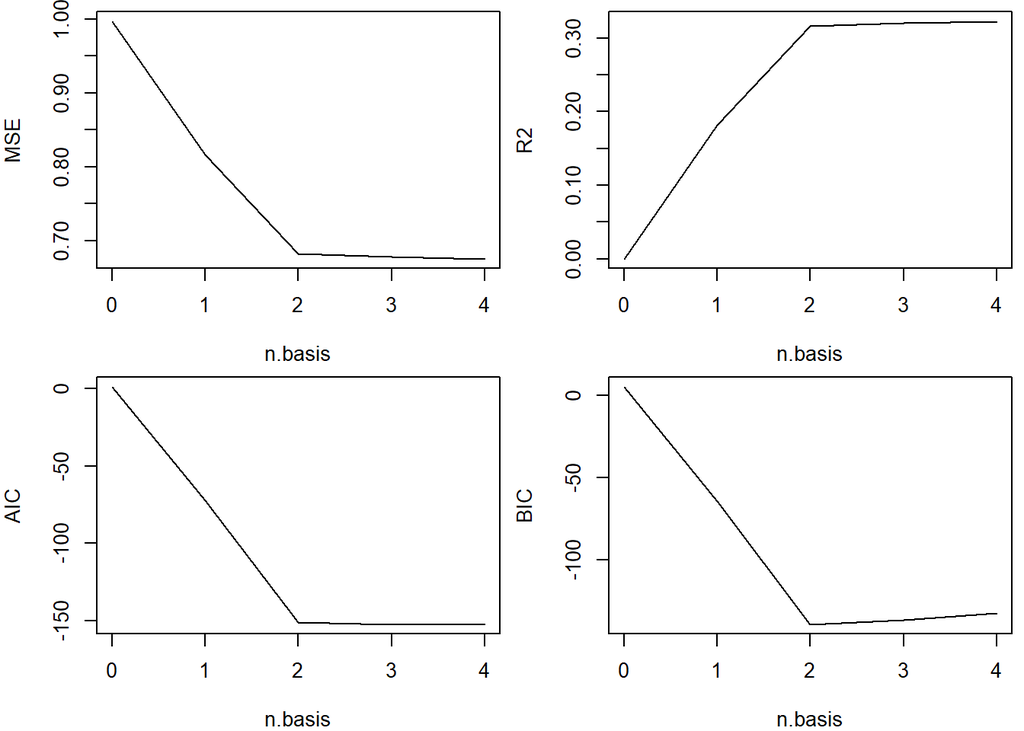

```r
plot(pol.SVD.cv.4py)
```

```r
#' Trying 8 df per year
pol.SVD.cv.8py <- SVDsmoothCV(D_pol, 0:4, df = n_years * 8)
print(pol.SVD.cv.8py)
```

```
## Result of SVDsmoothCV, average of CV-statistics:
##                 MSE        R2          AIC         BIC
## n.basis.0 0.9969766 0.0000000    0.9984844    4.900373
## n.basis.1 0.7699052 0.2278010  -95.3468488  -87.543072
## n.basis.2 0.6146966 0.3834572 -190.2518105 -178.546146
## n.basis.3 0.6103707 0.3877984 -191.9253981 -176.317845
## n.basis.4 0.6107824 0.3873872 -189.6692624 -170.159821
```

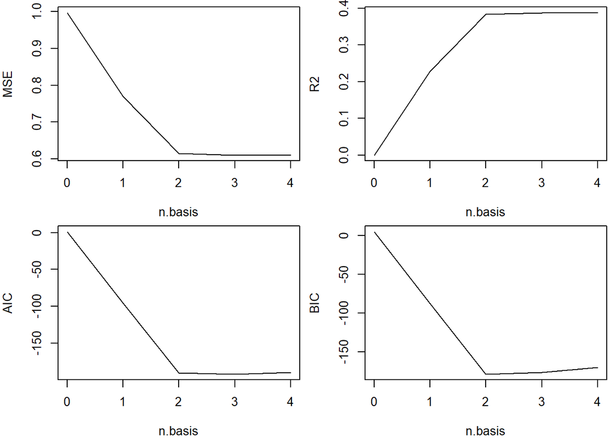

```r
plot(pol.SVD.cv.8py)
```

## 2.4 Plot the time trends

I tried using 1 and 2 basis functions for the time trends. I also checked out 4 and 8 df per year

### 2.4.1 1 basis function

First, see what the time trends for the monitoring data look like with 1 basis function.

**4 df per year**

```r
pol_STdata1 <- updateTrend(pol_STdata, n.basis = 1, df = n_years * 4)
```

```
## Replacing existing trend.
```

```r
pol_STdata1
```

```
## STdata-object with:
##  No. locations: 17 (observed: 16)
##  No. time points: 521 (observed: 521)
##  No. obs: 5292
##
## Trend with 1 basis function(s):
## [1] "V1"
## with dates:
##  2008-12-29 to 2018-12-31
##
## 5 covariate(s):
## [1] "ID"  "x"   "y"   "lon" "lat"
##
## No spatio-temporal covariates.
```

```r
head(pol_STdata1$trend)
```

|  | V1 | date |
| --- | --- | --- |
| 1 | -2.443391 | 2008-12-29 |
| 2 | -2.209168 | 2009-01-05 |
| 3 | -1.979139 | 2009-01-12 |
| 4 | -1.758476 | 2009-01-19 |
| 5 | -1.552350 | 2009-01-26 |
| 6 | -1.365127 | 2009-02-02 |

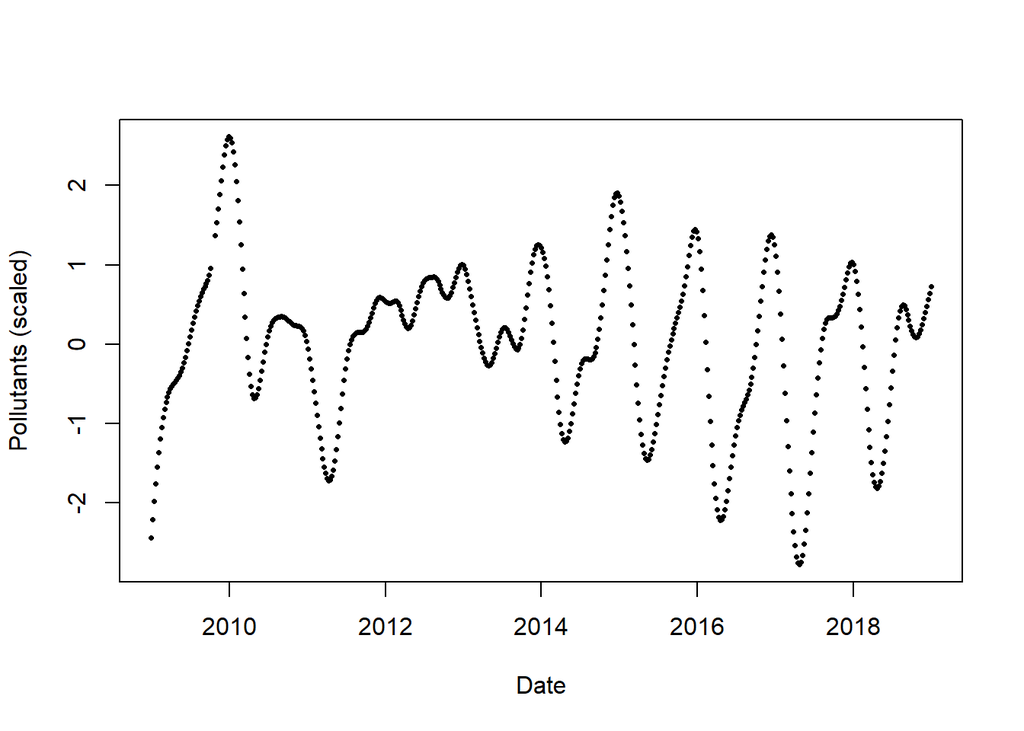

```r
plot(pol_STdata1$trend$date, pol_STdata1$trend$V1, col = 1, pch = 16, cex = 0.5,
     xlab = "Date", ylab = "Pollutants (scaled)")
lines(pol_STdata1$trend$date, pol_STdata1$atrend$V1, col = 1)
```

**8 df per year**

```r
pol_STdata1a <- updateTrend(pol_STdata, n.basis = 1, df = n_years * 8)
```

```
## Replacing existing trend.
```

```r
pol_STdata1a
```

```
## STdata-object with:
##  No. locations: 17 (observed: 16)
##  No. time points: 521 (observed: 521)
##  No. obs: 5292
##
## Trend with 1 basis function(s):
## [1] "V1"
## with dates:
##  2008-12-29 to 2018-12-31
##
## 5 covariate(s):
## [1] "ID"  "x"   "y"   "lon" "lat"
##
## No spatio-temporal covariates.
```

```r
head(pol_STdata1a$trend)
```

|  | V1 | date |
| --- | --- | --- |
| 1 | -2.5931759 | 2008-12-29 |
| 2 | -2.0965003 | 2009-01-05 |
| 3 | -1.6313579 | 2009-01-12 |
| 4 | -1.2229752 | 2009-01-19 |
| 5 | -0.8965789 | 2009-01-26 |
| 6 | -0.6692224 | 2009-02-02 |

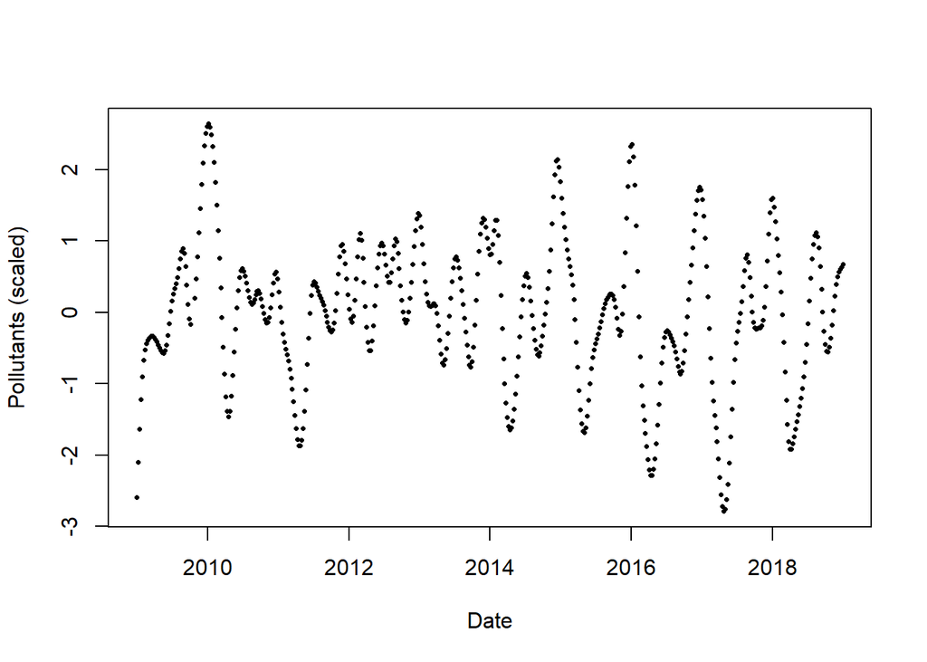

```r
plot(pol_STdata1a$trend$date, pol_STdata1a$trend$V1, col = 1, pch = 16, cex = 0.5,
     xlab = "Date", ylab = "Pollutants (scaled)")
lines(pol_STdata1a$trend$date, pol_STdata1a$atrend$V1, col = 1)
```

### 2.4.2 2 basis functions

Next, let’s see what 2 basis functions look like:

**4 df per year**

```r
pol_STdata2 <- updateTrend(pol_STdata, n.basis = 2, df = n_years * 4)
```

```
## Replacing existing trend.
```

```r
pol_STdata2
```

```
## STdata-object with:
##  No. locations: 17 (observed: 16)
##  No. time points: 521 (observed: 521)
##  No. obs: 5292
##
## Trend with 2 basis function(s):
## [1] "V1" "V2"
## with dates:
##  2008-12-29 to 2018-12-31
##
## 5 covariate(s):
## [1] "ID"  "x"   "y"   "lon" "lat"
##
## No spatio-temporal covariates.
```

```r
head(pol_STdata2$trend)
```

|  | V1 | V2 | date |
| --- | --- | --- | --- |
| 1 | -1.5359478 | 1.5821181 | 2008-12-29 |
| 2 | -1.4003880 | 1.4037021 | 2009-01-05 |
| 3 | -1.2697269 | 1.2235708 | 2009-01-12 |
| 4 | -1.1495758 | 1.0404582 | 2009-01-19 |
| 5 | -1.0455461 | 0.8530986 | 2009-01-26 |
| 6 | -0.9623784 | 0.6604231 | 2009-02-02 |

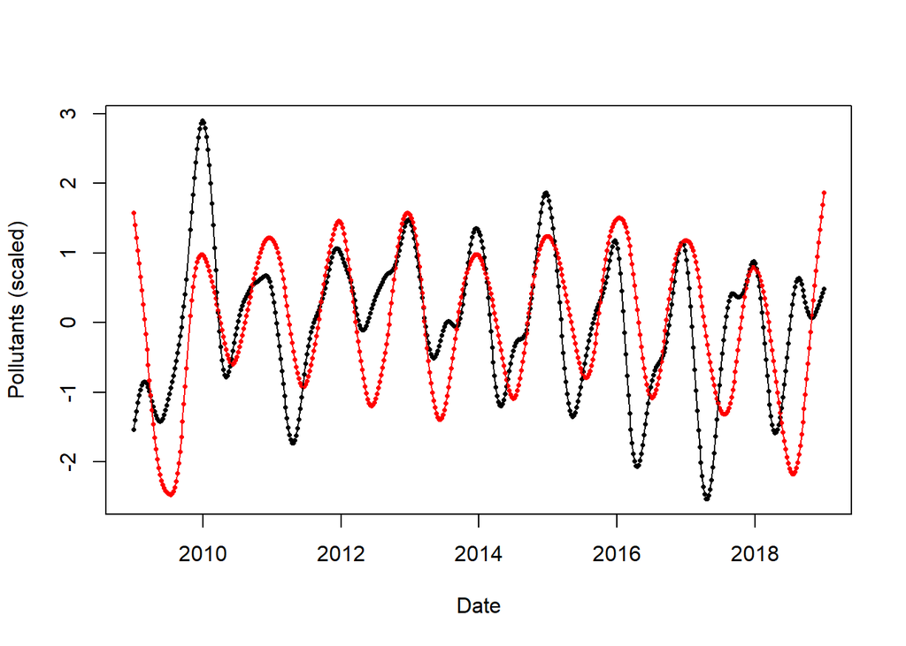

```r
plot(pol_STdata2$trend$date, pol_STdata2$trend$V1, col = 1, pch = 16, cex = 0.5,
     xlab = "Date", ylab = "Pollutants (scaled)")
points(pol_STdata2$trend$date, pol_STdata2$trend$V2, col = 2, pch = 16, cex = 0.5)
lines(pol_STdata2$trend$date, pol_STdata2$trend$V1, col = 1)
lines(pol_STdata2$trend$date, pol_STdata2$trend$V2, col = 2)
```

**8 df per year**

```r
pol_STdata2a <- updateTrend(pol_STdata, n.basis = 2, df = n_years * 8)
```

```
## Replacing existing trend.
```

```r
pol_STdata2a
```

```
## STdata-object with:
##  No. locations: 17 (observed: 16)
##  No. time points: 521 (observed: 521)
##  No. obs: 5292
##
## Trend with 2 basis function(s):
## [1] "V1" "V2"
## with dates:
##  2008-12-29 to 2018-12-31
##
## 5 covariate(s):
## [1] "ID"  "x"   "y"   "lon" "lat"
##
## No spatio-temporal covariates.
```

```r
head(pol_STdata2a$trend)
```

|  | V1 | V2 | date |
| --- | --- | --- | --- |
| 1 | -2.0562264 | 1.1329898 | 2008-12-29 |
| 2 | -1.5788583 | 1.1081630 | 2009-01-05 |
| 3 | -1.1410861 | 1.0628391 | 2009-01-12 |
| 4 | -0.7687693 | 0.9942480 | 2009-01-19 |
| 5 | -0.4877674 | 0.8996198 | 2009-01-26 |
| 6 | -0.3154096 | 0.7774621 | 2009-02-02 |

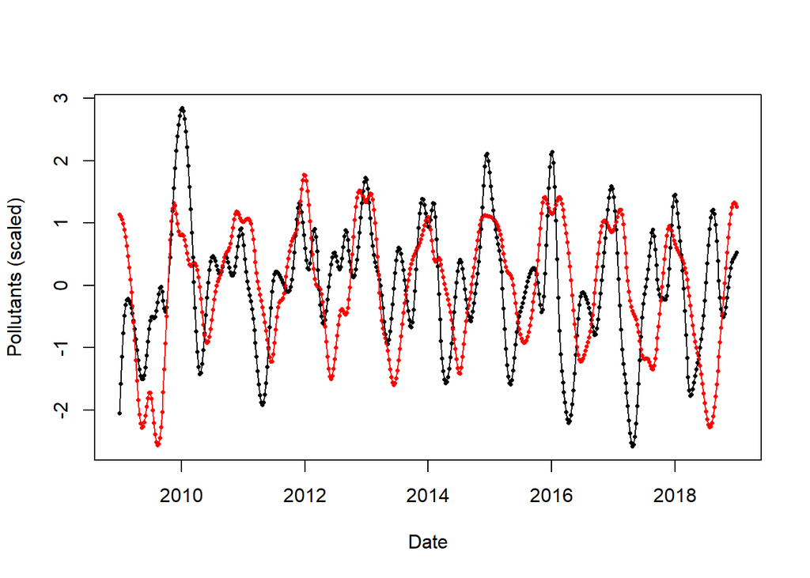

```r
plot(pol_STdata2a$trend$date, pol_STdata2a$trend$V1, col = 1, pch = 16, cex = 0.5,
     xlab = "Date", ylab = "Pollutants (scaled)")
points(pol_STdata2a$trend$date, pol_STdata2a$trend$V2, col = 2, pch = 16, cex = 0.5)
lines(pol_STdata2a$trend$date, pol_STdata2a$trend$V1, col = 1)
lines(pol_STdata2a$trend$date, pol_STdata2a$trend$V2, col = 2)
```

Note that the two basis function plot based on the updated monitoring data set (which includes PM2.5) looks different from when it did with just the NO2 and BC data